# Basic Plots in ggplot2

2016-06-22

## Let's Run the Setup File…

You should see a plot appear if setup is successful.

## ggplot2 In a Nutshell

- Wildly popular package for statistical graphics: over 1.75 million downloads from CRAN in 2015 (~ 6,200 times per day)
- Developed by Hadley Wickham (An ISU Alumni)
- Designed to adhere to good graphical practices
- Supports a wide variety plot types
- Constructs plots using the concept of layers
- http://ggplot2.org/book/ or Hadley's book *ggplot2: Elegant Graphics for Data Analysis* for reference material

## *qplot* Function

The *qplot()* function is the basic workhorse of ggplot2

- Produces all plot types available with ggplot2
- Allows for plotting options within the function statement
- Creates an object that can be saved
- Plot layers can be added to modify plot complexity

## *qplot* Structure

The *qplot()* function has a basic syntax:

*qplot(variables, plot type, dataset, options)*

- variables: list of variables used for the plot
- plot type: specified with a *geom =* statement
- dataset: specified with a *data =* statement
- options: there are so, so many options!

## Diamonds Data

We will explore the diamonds data set (preloaded along with ggplot2) using qplot for basic plotting.

The data set was scraped from a diamond exchange company data base by Hadley. It contains the prices and attributes of over 50,000 diamonds

## Examining the Diamonds Data

What does the data look like?

Lets look at the top few rows of the diamond data frame to find out!

```r
head(diamonds)
```

```
##   carat       cut color clarity depth table price    x    y    z
## 1  0.23     Ideal     E     SI2  61.5    55   326 3.95 3.98 2.43
## 2  0.21   Premium     E     SI1  59.8    61   326 3.89 3.84 2.31
## 3  0.23      Good     E     VS1  56.9    65   327 4.05 4.07 2.31
## 4  0.29   Premium     I     VS2  62.4    58   334 4.20 4.23 2.63
## 5  0.31      Good     J     SI2  63.3    58   335 4.34 4.35 2.75
## 6  0.24 Very Good     J    VVS2  62.8    57   336 3.94 3.96 2.48
```

## Basic Scatterplot

Basic scatter plot of diamond price vs carat weight

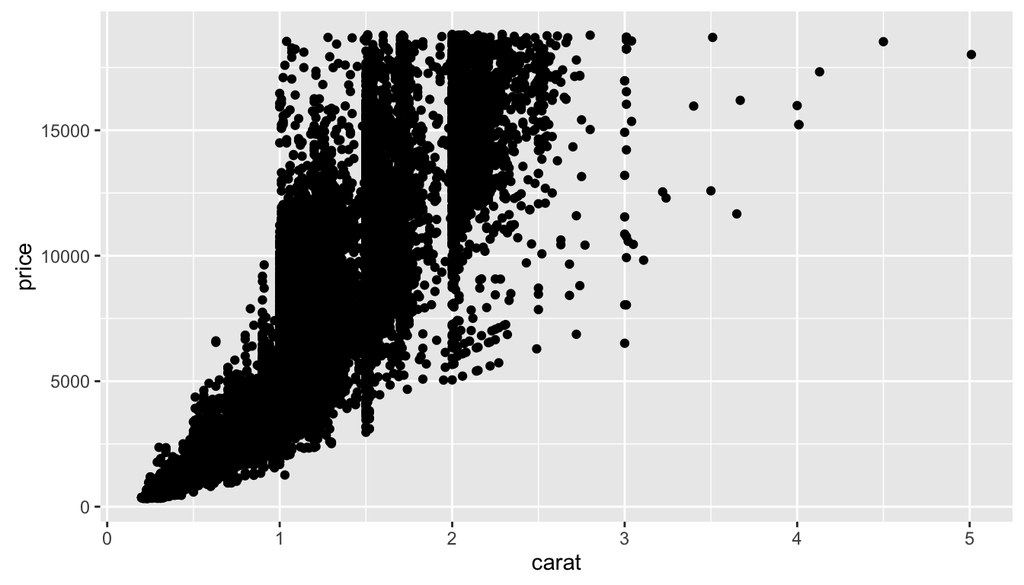

```r
qplot(carat, price, geom = "point", data = diamonds)
```

## Another Scatterplot

Scatter plot of diamond price vs carat weight showing versitility of options in qplot

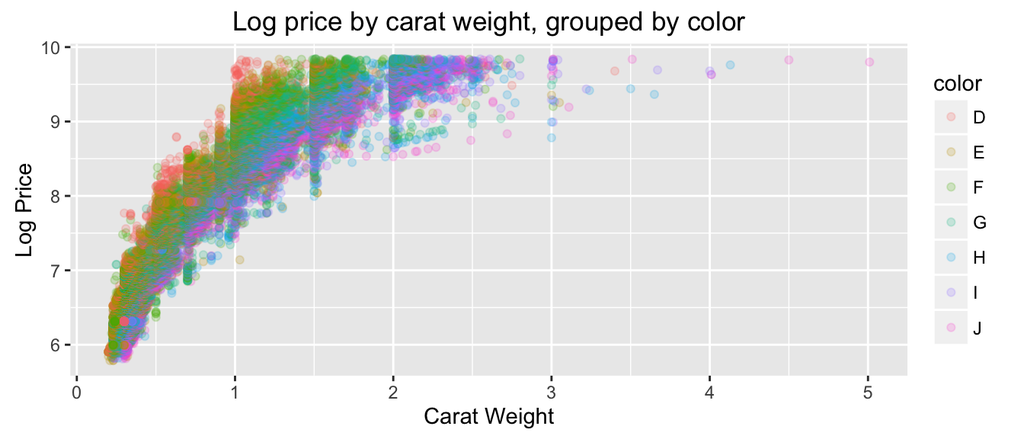

```r
qplot(carat, log(price), geom = "point", data = diamonds,
    alpha = I(0.2), colour = color,
    main = "Log price by carat weight, grouped by color") +
    xlab("Carat Weight") + ylab("Log Price")
```

## Your Turn

All of the your turns for this section will use the tips data set:

```r
tips <- read.csv("http://heike.github.io/rwrks/summerschool/data/tips.csv")
```

1. Use qplot to build a scatterplot of variables tips and total bill
2. Use options within qplot to color points by smokers
3. Clean up axis labels and add main plot title

## Basic Histogram

Basic histogram of price

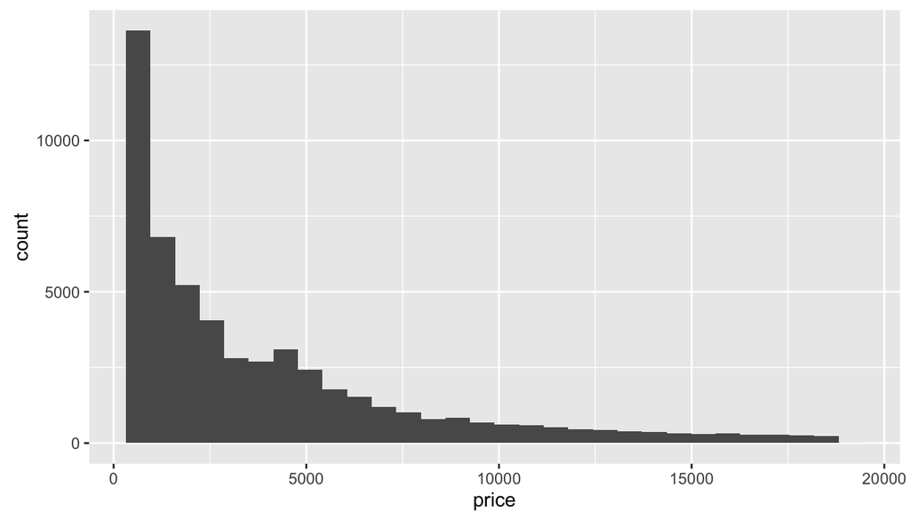

```r
qplot(price, geom = "histogram", data = diamonds)
```

## Why setting the bin width is useful

Histogram of price, binwidth is set to $50

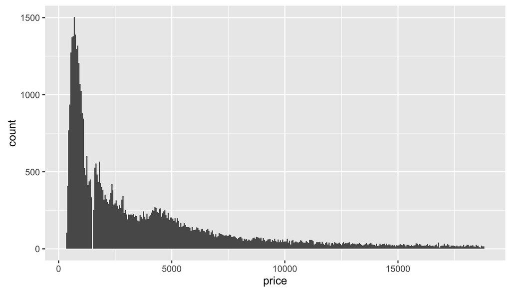

```r
qplot(price, geom = "histogram",  binwidth = 50, data = diamonds)
```

## Another Histogram

Price histograms faceted by clarity

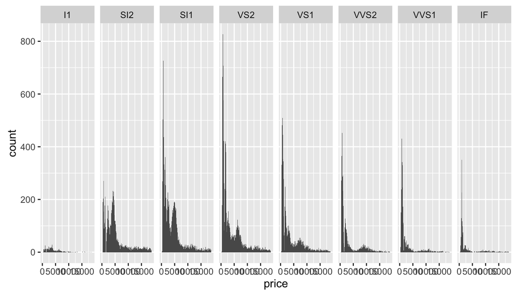

```r
qplot(price, geom = "histogram", data = diamonds, binwidth = 100, facets = .~clarity)
```

## Your Turn

1. Create a new variable in tips data frame rate = tip / total bill
2. Use qplot to create a histogram of rate
3. Change the bin width on that histogram to 0.05
4. Facet this histogram by size of the group

## Basic Boxplot

Side by side boxplot of diamond prices within clarity groupings

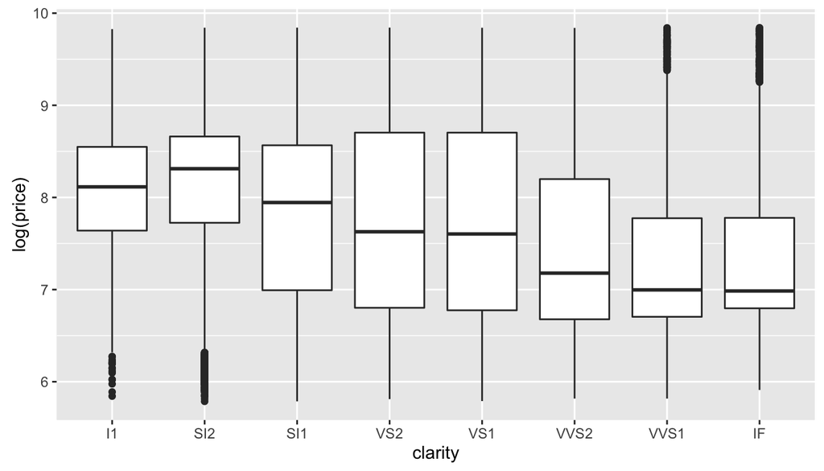

```r
qplot(clarity, log(price), geom = "boxplot", data = diamonds)
```

Why does price decrease as the quality of the diamonds increases?

## Another Boxplot

Side by side boxplot of log prices within clarity groupings with jittered values overlay

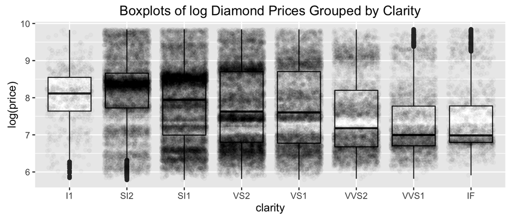

```r
qplot(clarity, log(price), geom = "boxplot", data = diamonds,
    main = "Boxplots of log Diamond Prices Grouped by Clarity") +
    geom_jitter(alpha = I(.025))
```

There are two groups of prices … maybe related to size?

## Another Boxplot

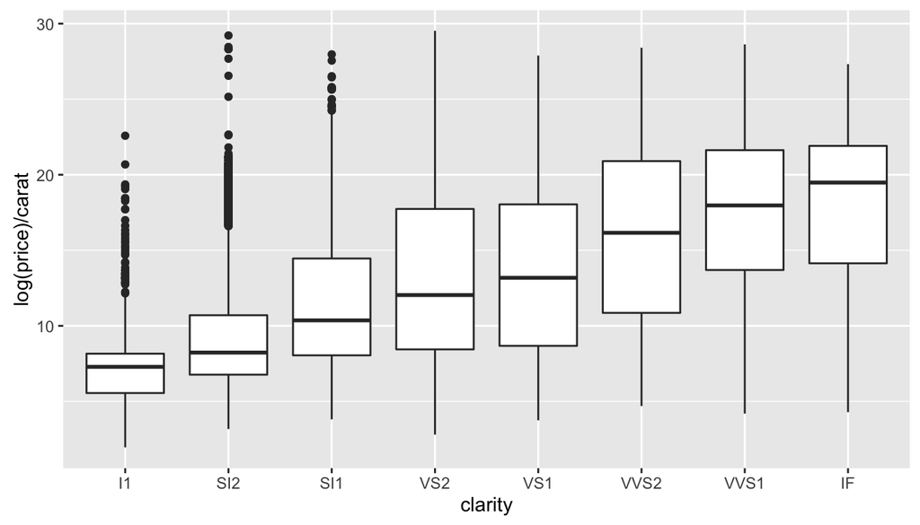

```r
qplot(clarity, log(price)/carat, geom = "boxplot", data = diamonds)
```

## Your Turn

1. Make side by side boxplots of tipping rate for males and females
2. Overlay jittered points for observed values onto this boxplot

## Bar Plots

To investigate bar plots we will switch over to the Titanic data set:

```r
titanic <- as.data.frame(Titanic)
```

Data includes passenger characteristics and survival outcomes for those aboard the RMS Titanic's ill fated maiden voyage

## Basic Bar Plot

Basic bar plot of survival outcomes

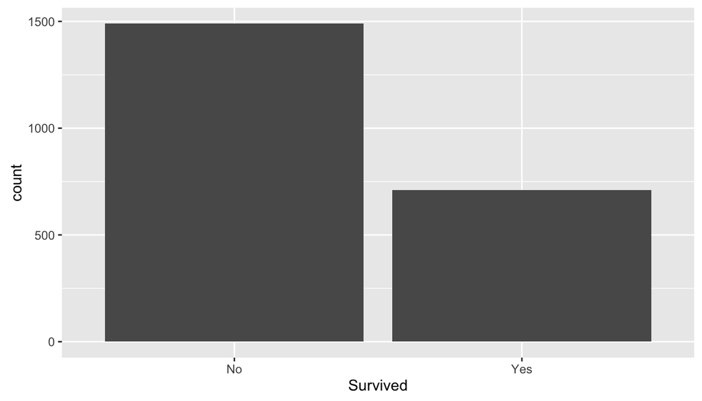

```r
qplot(Survived, geom = "bar", data = titanic, weight = Freq)
```

## Another Bar Plot

Bar plot faceted by gender and class

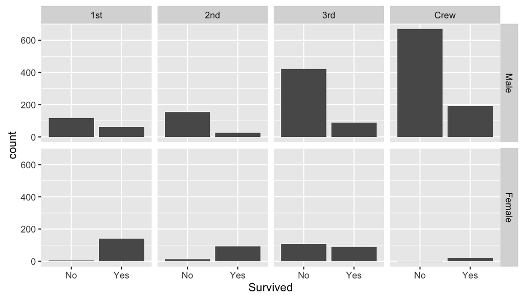

```r
qplot(Survived, geom = "bar", data = titanic, weight = Freq,
      facets = Sex~Class)
```

## Your Turn

1. Use the tips data to make a barplot for counts of smoking and non smoking customers
2. Facet using day of week and time of day to view how smoking status changes for different meal times